# Hypertuning

Rithin

2/7/2020

# The IMDB dataset

Load IMDB dataset The IMDB dataset is preloaded in the Keras

```r
library(keras)
library(tensorflow)
library(tidyverse)
```

```r
library(cowplot)
imdb <- dataset_imdb(num_words = 10000)
c(c(train_data, train_labels), c(test_data, test_labels)) %<-% imdb
```

The argument num_words = 10000 means that we will only keep the top 10,000 most frequently occurring words in the training data. Rare words will be discarded

The variables train_data and test_data are lists of reviews, each review being a list of word indices (encoding a sequence of words). train_labels and test_labels are lists of 0s and 1s, where 0 stands for “negative” and 1 stands for “positive”:

# Preparing the Data

```r
vectorize_sequences <- function(sequences, dimension = 10000) {
  # Create an all-zero matrix of shape (len(sequences), dimension)
  results <- matrix(0, nrow = length(sequences), ncol = dimension)
  for (i in 1:length(sequences))
    # Sets specific indices of results[i] to 1s
    results[i, sequences[[i]]] <- 1
  results
}

# Our vectorized training data
x_train <- vectorize_sequences(train_data)
# Our vectorized test data
x_test <- vectorize_sequences(test_data)
# Our vectorized labels
y_train <- as.numeric(train_labels)
y_test <- as.numeric(test_labels)
set.seed(123)
val_indices <- sample(1:nrow(x_train),nrow(x_train)*0.40)

x_val <- x_train[val_indices,]
partial_x_train <- x_train[-val_indices,]

y_val <- y_train[val_indices]
partial_y_train <- y_train[-val_indices]
```

# 1-hidden layer network without any technique

1-hidden layer network with 16 units tanh activation mse loss function

```r
model <- keras_model_sequential() %>%
  layer_dense(units = 16, activation = "tanh", input_shape = c(10000)) %>%
  layer_dense(units = 1, activation = "sigmoid")


model %>% compile(
  optimizer = "rmsprop",
  loss = "mse",
  metrics = c("accuracy")
)

history <- model %>% fit(
  partial_x_train,
  partial_y_train,
  epochs = 20,
  batch_size = 512,
  validation_data = list(x_val, y_val)
)

str(history)
```

```
## List of 2
##  $ params :List of 7
##   ..$ batch_size   : int 512
##   ..$ epochs       : int 20
##   ..$ steps        : num 30
##   ..$ samples      : int 15000
##   ..$ verbose      : int 0
##   ..$ do_validation: logi TRUE
##   ..$ metrics      : chr [1:4] "loss" "accuracy" "val_loss" "val_accuracy"
##  $ metrics:List of 4
##   ..$ loss        : num [1:20] 0.1651 0.0994 0.0747 0.0597 0.049 ...
##   ..$ accuracy    : num [1:20] 0.797 0.901 0.925 0.942 0.952 ...
##   ..$ val_loss    : num [1:20] 0.1286 0.1024 0.089 0.083 0.0821 ...
##   ..$ val_accuracy: num [1:20] 0.858 0.879 0.89 0.892 0.893 ...
##  - attr(*, "class")= chr "keras_training_history"
```

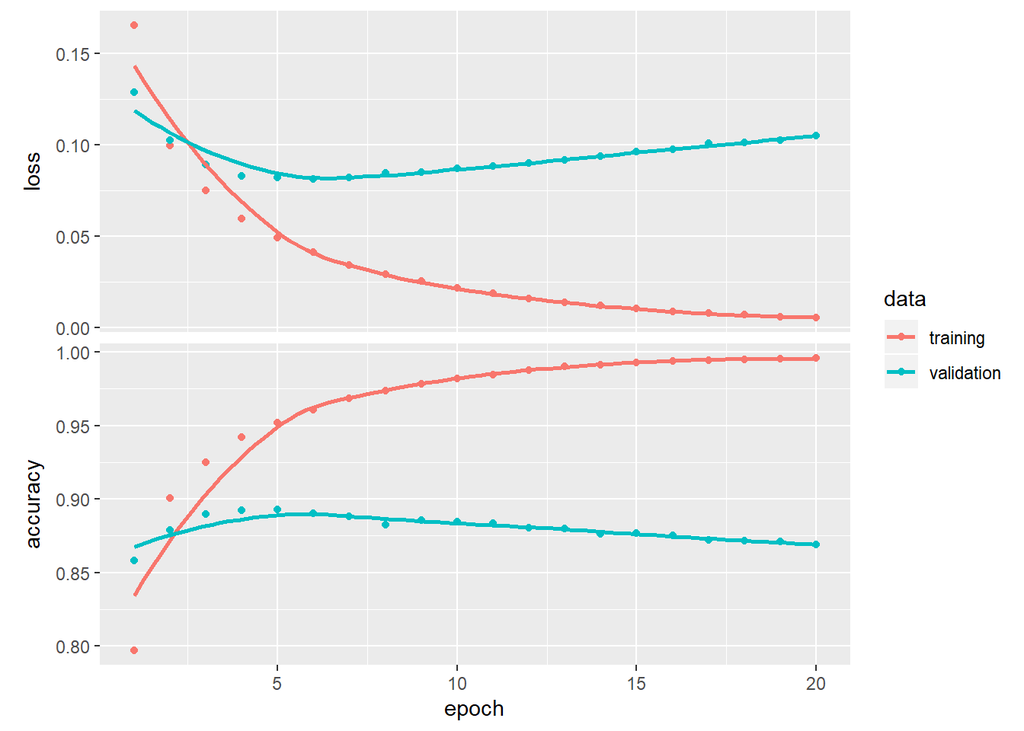

```r
plot(history)
```

```r
model %>% fit(x_train, y_train, epochs = 3, batch_size = 512)
results <- model %>% evaluate(x_test, y_test)

results
```

```
## $loss
## [1] 0.1129772
##
## $accuracy
## [1] 0.8592
```

```r
model %>% predict(x_test[1:10,])
```

```
##               [,1]
##  [1,] 2.503252e-02
##  [2,] 9.999893e-01
##  [3,] 9.980448e-01
##  [4,] 7.014790e-01
##  [5,] 9.915329e-01
##  [6,] 8.865103e-01
##  [7,] 9.999853e-01
##  [8,] 9.959936e-05
##  [9,] 9.978053e-01
## [10,] 9.977946e-01
```

This network begins to overfit after three epochs.

Here the validation Accuracy is 86% and loss of 12%. Let us try using regularization and drop out techniques

# 1- hidden layer network with regularization

1-hidden layer network with 16 units tanh activation mse loss function regularization technique

```r
model <- keras_model_sequential() %>%
  layer_dense(units = 16,  kernel_regularizer = regularizer_l2(.0001),activation = "tanh", input_shape = c(10000)) %>%
  layer_dense(units = 1, activation = "sigmoid")

model %>% compile(
  optimizer = "rmsprop",
  loss = "mse",
  metrics = c("accuracy")
)

history <- model %>% fit(
  partial_x_train,
  partial_y_train,
  epochs = 20,
  batch_size = 512,
  validation_data = list(x_val, y_val)
)

str(history)
```

```
## List of 2
##  $ params :List of 7
##   ..$ batch_size   : int 512
##   ..$ epochs       : int 20
##   ..$ steps        : num 30
##   ..$ samples      : int 15000
##   ..$ verbose      : int 0
##   ..$ do_validation: logi TRUE
##   ..$ metrics      : chr [1:4] "loss" "accuracy" "val_loss" "val_accuracy"
##  $ metrics:List of 4
##   ..$ loss        : num [1:20] 0.1623 0.0979 0.0761 0.064 0.0561 ...
##   ..$ accuracy    : num [1:20] 0.8 0.904 0.928 0.942 0.952 ...
##   ..$ val_loss    : num [1:20] 0.1189 0.1061 0.0918 0.0932 0.0939 ...
##   ..$ val_accuracy: num [1:20] 0.877 0.876 0.891 0.888 0.887 ...
##  - attr(*, "class")= chr "keras_training_history"
```

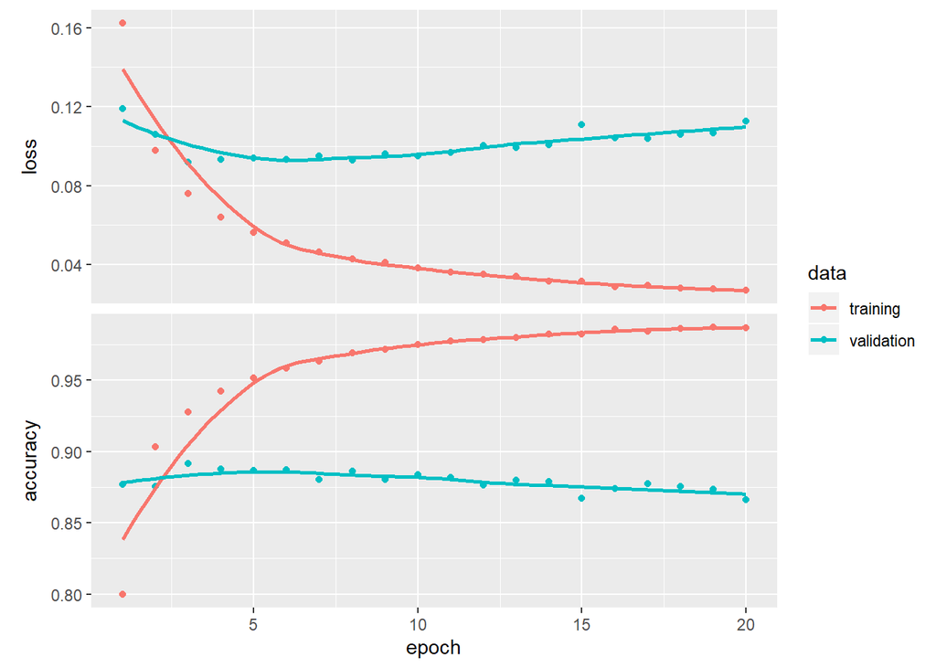

```r
plot(history)
```

```r
model %>% fit(x_train, y_train, epochs = 4, batch_size = 512)
results <- model %>% evaluate(x_test, y_test)

results
```

```
## $loss
## [1] 0.1190331
##
## $accuracy
## [1] 0.8582
```

```r
model %>% predict(x_test[1:10,])
```

```
##               [,1]
##  [1,] 0.0185901225
##  [2,] 0.9999846220
##  [3,] 0.6379750967
##  [4,] 0.5803411007
##  [5,] 0.9842956066
##  [6,] 0.7565318346
##  [7,] 0.9998965263
##  [8,] 0.0004416704
##  [9,] 0.9746053815
## [10,] 0.9956567287
```

This network begins to overfit after four epochs

# 1- Hidden layer network with regularization and drop out

1-hidden layer network with 16 units tanh activation mse loss function regularization and dropout techniques

```r
model <- keras_model_sequential() %>%
  layer_dense(units = 16,  kernel_regularizer = regularizer_l2(.0001),activation = "tanh", input_shape = c(10000)) %>%
  layer_dropout(rate = 0.5) %>%
  layer_dense(units = 1, activation = "sigmoid")

model %>% compile(
  optimizer = "rmsprop",
  loss = "mse",
  metrics = c("accuracy")
)

history <- model %>% fit(
  partial_x_train,
  partial_y_train,
  epochs = 20,
  batch_size = 512,
  validation_data = list(x_val, y_val)
)

str(history)
```

```
## List of 2
##  $ params :List of 7
##   ..$ batch_size   : int 512
##   ..$ epochs       : int 20
##   ..$ steps        : num 30
##   ..$ samples      : int 15000
##   ..$ verbose      : int 0
##   ..$ do_validation: logi TRUE
##   ..$ metrics      : chr [1:4] "loss" "accuracy" "val_loss" "val_accuracy"
##  $ metrics:List of 4
##   ..$ loss        : num [1:20] 0.1754 0.1137 0.0912 0.0768 0.0684 ...
##   ..$ accuracy    : num [1:20] 0.784 0.888 0.914 0.928 0.938 ...
##   ..$ val_loss    : num [1:20] 0.1424 0.1047 0.0958 0.0903 0.089 ...
##   ..$ val_accuracy: num [1:20] 0.827 0.886 0.889 0.891 0.892 ...
##  - attr(*, "class")= chr "keras_training_history"
```

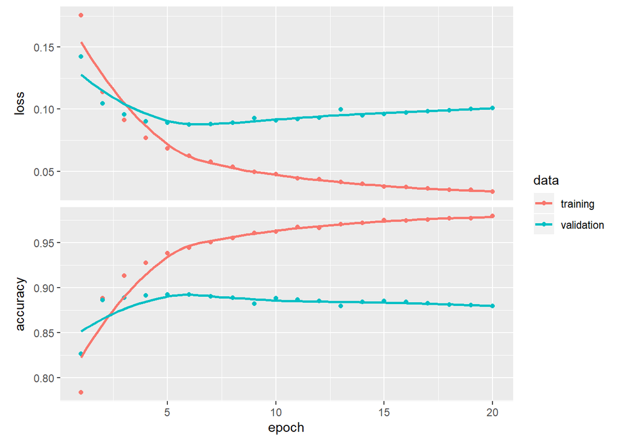

```r
plot(history)
```

```r
model %>% fit(x_train, y_train, epochs = 5, batch_size = 512)
results <- model %>% evaluate(x_test, y_test)

results
```

```
## $loss
## [1] 0.1062023
##
## $accuracy
## [1] 0.87272
```

```r
model %>% predict(x_test[1:10,])
```

```
##              [,1]
##  [1,] 0.023825765
##  [2,] 0.999994516
##  [3,] 0.920240641
##  [4,] 0.880792320
##  [5,] 0.989270687
##  [6,] 0.845813036
##  [7,] 0.999958038
##  [8,] 0.001800418
##  [9,] 0.990712583
## [10,] 0.999444664
```

This network begins to overfit after five epochs

# 3- Hidden layer network without regualrization and dropout

3-hidden layer network with 64, 32 and 16 units tanh activation mse loss function

```r
model <- keras_model_sequential() %>%
  layer_dense(units = 64, activation = "tanh", input_shape = c(10000)) %>%
  layer_dense(units = 32, activation = "tanh") %>%
  layer_dense(units = 16, activation = "tanh") %>%
  layer_dense(units = 1, activation = "sigmoid")

model %>% compile(
  optimizer = "rmsprop",
  loss = "mse",
  metrics = c("accuracy")
)

history <- model %>% fit(
  partial_x_train,
  partial_y_train,
  epochs = 20,
  batch_size = 512,
  validation_data = list(x_val, y_val)
)

str(history)
```

```
## List of 2
##  $ params :List of 7
##   ..$ batch_size   : int 512
##   ..$ epochs       : int 20
##   ..$ steps        : num 30
##   ..$ samples      : int 15000
##   ..$ verbose      : int 0
##   ..$ do_validation: logi TRUE
##   ..$ metrics      : chr [1:4] "loss" "accuracy" "val_loss" "val_accuracy"
##  $ metrics:List of 4
##   ..$ loss        : num [1:20] 0.1577 0.0704 0.0501 0.0432 0.0307 ...
##   ..$ accuracy    : num [1:20] 0.771 0.91 0.934 0.945 0.962 ...
##   ..$ val_loss    : num [1:20] 0.0939 0.1175 0.0983 0.0906 0.1107 ...
##   ..$ val_accuracy: num [1:20] 0.878 0.841 0.87 0.882 0.859 ...
##  - attr(*, "class")= chr "keras_training_history"
```

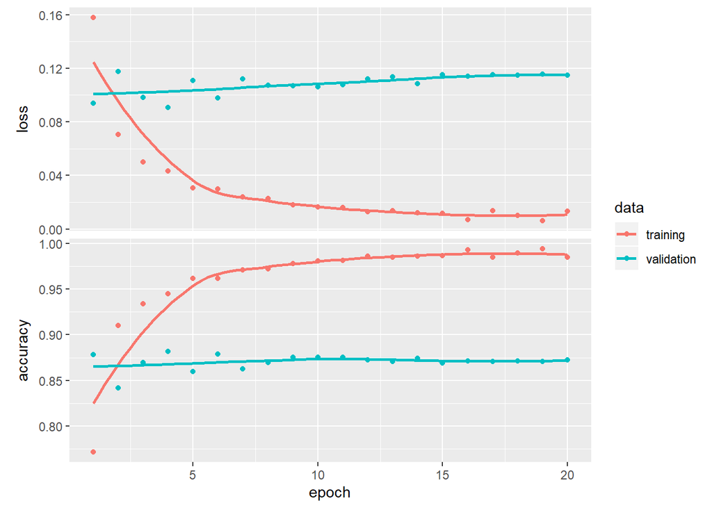

```r
plot(history)
```

```r
model %>% fit(x_train, y_train, epochs = 2, batch_size = 512)
results <- model %>% evaluate(x_test, y_test)

results
```

```
## $loss
## [1] 0.1137682
##
## $accuracy
## [1] 0.8632
```

```r
model %>% predict(x_test[1:10,])
```

```
##              [,1]
##  [1,] 0.011407793
##  [2,] 0.993270457
##  [3,] 0.988667607
##  [4,] 0.972742438
##  [5,] 0.987841487
##  [6,] 0.874405622
##  [7,] 0.992917538
##  [8,] 0.006464809
##  [9,] 0.992472649
## [10,] 0.991072357
```

This network begins to overfit after two epochs

Here the validation Accuracy is 86% and loss of 11%. We can try to improve the model by using regularization with the same hidden layers.

# 3-layer network with regualrization

3-hidden layer network with 64, 32 and 16 units tanh activation mse loss function regularization technique

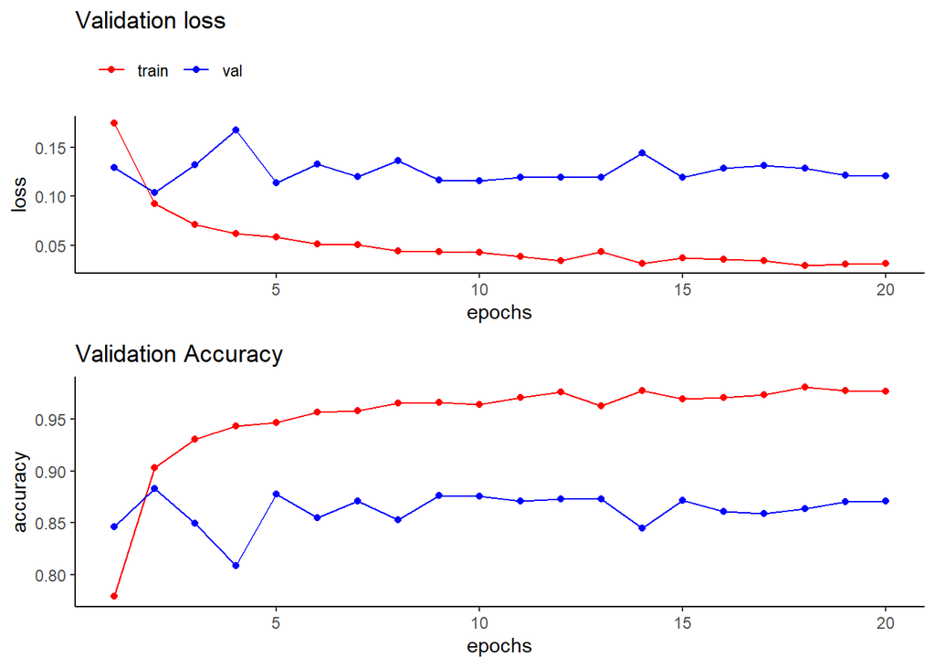

```r
model <- keras_model_sequential() %>%
  layer_dense(units = 64, kernel_regularizer = regularizer_l2(.0001), activation = "tanh", input_shape = c(10000)) %>%
  layer_dense(units = 32, kernel_regularizer = regularizer_l2(.0001), activation = "tanh") %>%
  layer_dense(units = 16, kernel_regularizer = regularizer_l2(.0001), activation = "tanh") %>%
  layer_dense(units = 1, activation = "sigmoid")

model %>% compile(
  optimizer = "rmsprop",
  loss = "mse",
  metrics = c("accuracy")
)

history <- model %>% fit(
  partial_x_train,
  partial_y_train,
  epochs = 20,
  batch_size = 512,
  validation_data = list(x_val, y_val)
)
hist1 <- as.data.frame(history$metrics)
names(hist1) <- c("train-loss","train-accuracy","val_loss","val_accuracy")
hist1 <- hist1 %>% mutate(epochs = 1:n()) %>% gather("split","values",-epochs) %>% separate(split,c("split","metric")) %>% spread(metric,values)

g1<- ggplot(hist1,aes(x=epochs,y=loss,color=split)) + geom_point() + geom_line() + theme_classic() + ggtitle("Validation loss") + theme(legend.position = "top",legend.justification = "left",legend.title = element_blank()) +scale_color_manual(values = c("red","blue"))
g2<- ggplot(hist1,aes(x=epochs,y=accuracy,color=split)) + geom_point(show.legend = F) + geom_line(show.legend = F) + theme_classic() + ggtitle("Validation Accuracy") + theme(legend.position = "top",legend.justification = "left",legend.title = element_blank()) + scale_color_manual(values = c("red","blue"))
plot_grid(g1,g2,nrow=2)
```

```r
str(history)
```

```
## List of 2
##  $ params :List of 7
##   ..$ batch_size   : int 512
##   ..$ epochs       : int 20
##   ..$ steps        : num 30
##   ..$ samples      : int 15000
##   ..$ verbose      : int 0
##   ..$ do_validation: logi TRUE
##   ..$ metrics      : chr [1:4] "loss" "accuracy" "val_loss" "val_accuracy"
##  $ metrics:List of 4
##   ..$ loss        : num [1:20] 0.1745 0.0926 0.071 0.0617 0.0587 ...
##   ..$ accuracy    : num [1:20] 0.779 0.903 0.931 0.944 0.947 ...
##   ..$ val_loss    : num [1:20] 0.129 0.104 0.132 0.168 0.114 ...
##   ..$ val_accuracy: num [1:20] 0.846 0.883 0.849 0.809 0.877 ...
##  - attr(*, "class")= chr "keras_training_history"
```

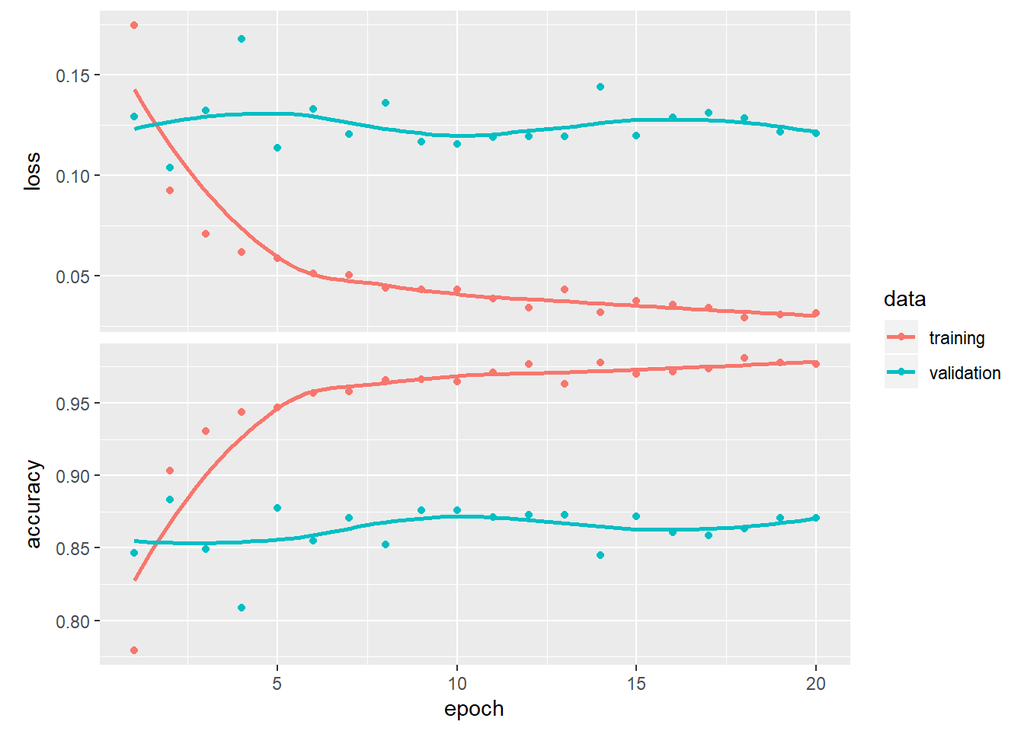

```r
plot(history)
```

```r
model %>% fit(x_train, y_train, epochs = 3, batch_size = 512)
results <- model %>% evaluate(x_test, y_test)

results
```

```
## $loss
## [1] 0.117962
##
## $accuracy
## [1] 0.86492
```

```r
model %>% predict(x_test[1:10,])
```

```
##              [,1]
##  [1,] 0.055855215
##  [2,] 0.997473240
##  [3,] 0.906449676
##  [4,] 0.681539059
##  [5,] 0.986043572
##  [6,] 0.768187881
##  [7,] 0.997329593
##  [8,] 0.004764676
##  [9,] 0.988600552
## [10,] 0.992869079
```

# 3-layer network with regualrization

3-hidden layer network with 64, 32 and 16 units relu activation mse loss function regularization technique

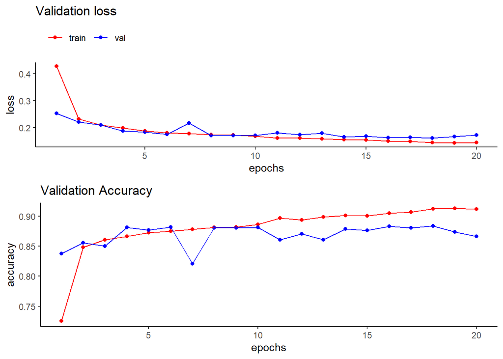

```r
model <- keras_model_sequential() %>%
  layer_dense(units = 64, kernel_regularizer = regularizer_l1(.0001), activation = "relu", input_shape = c(10000)) %>%
  layer_dense(units = 32, kernel_regularizer = regularizer_l1(.0001), activation = "relu") %>%
  layer_dense(units = 16, kernel_regularizer = regularizer_l1(.0001), activation = "relu") %>%
  layer_dense(units = 1, activation = "sigmoid")

model %>% compile(
  optimizer = "rmsprop",
  loss = "mse",
  metrics = c("accuracy")
)

history <- model %>% fit(
  partial_x_train,
  partial_y_train,
  epochs = 20,
  batch_size = 512,
  validation_data = list(x_val, y_val)
)
hist1 <- as.data.frame(history$metrics)
names(hist1) <- c("train-loss","train-accuracy","val_loss","val_accuracy")
hist1 <- hist1 %>% mutate(epochs = 1:n()) %>% gather("split","values",-epochs) %>% separate(split,c("split","metric")) %>% spread(metric,values)

g1<- ggplot(hist1,aes(x=epochs,y=loss,color=split)) + geom_point() + geom_line() + theme_classic() + ggtitle("Validation loss") + theme(legend.position = "top",legend.justification = "left",legend.title = element_blank()) +scale_color_manual(values = c("red","blue"))
g2<- ggplot(hist1,aes(x=epochs,y=accuracy,color=split)) + geom_point(show.legend = F) + geom_line(show.legend = F) + theme_classic() + ggtitle("Validation Accuracy") + theme(legend.position = "top",legend.justification = "left",legend.title = element_blank()) + scale_color_manual(values = c("red","blue"))
plot_grid(g1,g2,nrow=2)
```

```r
str(history)
```

```
## List of 2
##  $ params :List of 7
##   ..$ batch_size   : int 512
##   ..$ epochs       : int 20
##   ..$ steps        : num 30
##   ..$ samples      : int 15000
##   ..$ verbose      : int 0
##   ..$ do_validation: logi TRUE
##   ..$ metrics      : chr [1:4] "loss" "accuracy" "val_loss" "val_accuracy"
##  $ metrics:List of 4
##   ..$ loss        : num [1:20] 0.428 0.231 0.21 0.198 0.188 ...
##   ..$ accuracy    : num [1:20] 0.726 0.848 0.861 0.866 0.873 ...
##   ..$ val_loss    : num [1:20] 0.252 0.22 0.209 0.188 0.183 ...
##   ..$ val_accuracy: num [1:20] 0.838 0.856 0.85 0.881 0.877 ...
##  - attr(*, "class")= chr "keras_training_history"
```

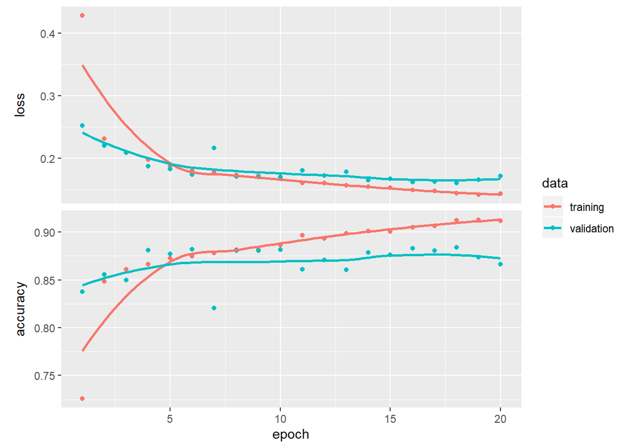

```r
plot(history)
```

```r
model %>% fit(x_train, y_train, epochs = 9, batch_size = 512)
results <- model %>% evaluate(x_test, y_test)

results
```

```
## $loss
## [1] 0.1548275
##
## $accuracy
## [1] 0.88168
```

```r
model %>% predict(x_test[1:10,])
```

```
##             [,1]
##  [1,] 0.09423950
##  [2,] 0.99788022
##  [3,] 0.92300463
##  [4,] 0.90903538
##  [5,] 0.96890604
##  [6,] 0.90906787
##  [7,] 0.98869652
##  [8,] 0.03107163
##  [9,] 0.96157110
## [10,] 0.98443800
```

# 3-Hidden layer network with regualrization and dropout

```r
model <- keras_model_sequential() %>%
  layer_dense(units = 32, kernel_regularizer = regularizer_l1(.001), activation = "tanh", input_shape = c(10000)) %>%
  layer_dropout(rate = 0.5) %>%
  layer_dense(units = 16, kernel_regularizer = regularizer_l1(.001), activation = "tanh") %>%
  layer_dropout(rate = 0.5) %>%
  layer_dense(units = 16, kernel_regularizer = regularizer_l1(.001), activation = "tanh") %>%
  layer_dropout(rate = 0.5) %>%
  layer_dense(units = 1, activation = "sigmoid")


model %>% compile(
  optimizer = "rmsprop",
  loss = "mse",
  metrics = c("accuracy")
)

history <- model %>% fit(
  partial_x_train,
  partial_y_train,
  epochs = 20,
  batch_size = 512,
  validation_data = list(x_val, y_val)
)

str(history)
```

```
## List of 2
##  $ params :List of 7
##   ..$ batch_size   : int 512
##   ..$ epochs       : int 20
##   ..$ steps        : num 30
##   ..$ samples      : int 15000
##   ..$ verbose      : int 0
##   ..$ do_validation: logi TRUE
##   ..$ metrics      : chr [1:4] "loss" "accuracy" "val_loss" "val_accuracy"
##  $ metrics:List of 4
##   ..$ loss        : num [1:20] 1.218 0.53 0.495 0.472 0.453 ...
##   ..$ accuracy    : num [1:20] 0.646 0.742 0.776 0.802 0.81 ...
##   ..$ val_loss    : num [1:20] 0.564 0.51 0.489 0.445 0.441 ...
##   ..$ val_accuracy: num [1:20] 0.752 0.798 0.792 0.821 0.825 ...
##  - attr(*, "class")= chr "keras_training_history"
```

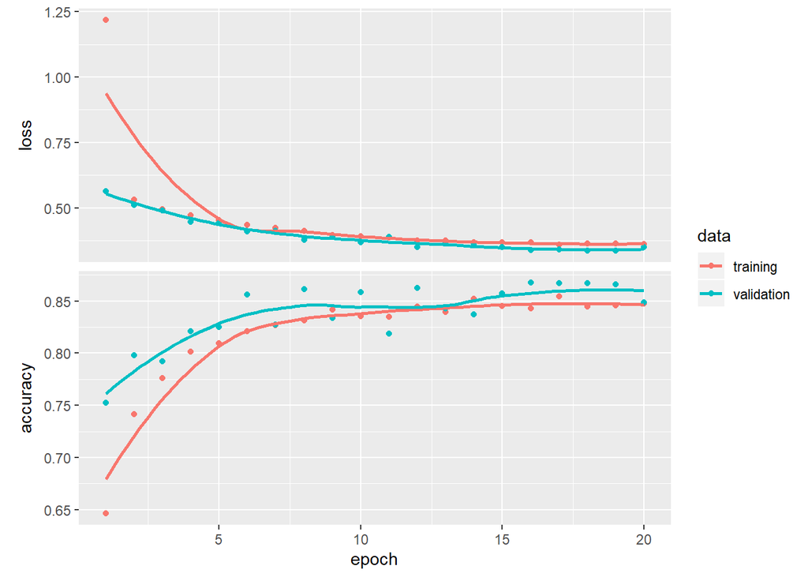

```r
plot(history)
```

```r
model %>% fit(x_train, y_train, epochs = 8, batch_size = 512)
results <- model %>% evaluate(x_test, y_test)

results
```

```
## $loss
## [1] 0.3555876
##
## $accuracy
## [1] 0.82964
```

```r
model %>% predict(x_test[1:10,])
```

```
##             [,1]
##  [1,] 0.35825139
##  [2,] 0.99808335
##  [3,] 0.96786386
##  [4,] 0.94838607
##  [5,] 0.94055104
##  [6,] 0.84557319
##  [7,] 0.98849535
##  [8,] 0.05995524
##  [9,] 0.97166741
## [10,] 0.98436397
```

let us test on the data

```r
model <- keras_model_sequential() %>%
  layer_dense(units = 64, kernel_regularizer = regularizer_l1(.0001), activation = "tanh", input_shape = c(10000)) %>%
  layer_dropout(rate = 0.5) %>%
  layer_dense(units = 32, kernel_regularizer = regularizer_l1(.0001), activation = "tanh") %>%
  layer_dropout(rate = 0.5) %>%
  layer_dense(units = 16, kernel_regularizer = regularizer_l1(.0001), activation = "tanh") %>%
  layer_dropout(rate = 0.5) %>%
  layer_dense(units = 1, activation = "sigmoid")

model %>% compile(
  optimizer = "rmsprop",
  loss = "mse",
  metrics = c("accuracy")
)
```

This method gives an accuracy of 88%

# Using a trained network to generate predictions on new data

```r
model %>% fit(x_train, y_train, epochs = 8, batch_size = 512)
results <- model %>% evaluate(x_test, y_test)

results
```

```
## $loss
## [1] 0.1947826
##
## $accuracy
## [1] 0.8818
```

```r
model %>% predict(x_test[1:10,])
```

```
##              [,1]
##  [1,] 0.048086882
##  [2,] 0.995303273
##  [3,] 0.941547751
##  [4,] 0.866679788
##  [5,] 0.963416934
##  [6,] 0.771879435
##  [7,] 0.992357790
##  [8,] 0.007214278
##  [9,] 0.979522824
## [10,] 0.979907036
```